# VAERS Exploration

davegoblue

2022-06-24

## Background

This module explores vaccine adverse events (VAERS) in the United States, based on data available at [HHS - VAERS](https://vaers.hhs.gov/data/datasets.html). Data are maintained on reported adverse events by vaccine, symptom or sign, year, etc. Because VAERS is a reporting system, it may include over-reporting of adverse events (e.g., false reports, errors, spurious correlation, etc.) and under-reporting of adverse events (e.g., patient or doctor is not aware of system or chooses not to spend time reporting). While there is under-reporting and over-reporting in VAERS, it is widely believed that VAERS significantly underestimates adverse events. This under-reporting ratio may differ by attributes such as vaccine, symptom, etc.

The code leverages tidyverse and sourced functions throughout:

```r
# All functions assume that tidyverse and its components are loaded and available
library(tidyverse)
# Generic added R functions will be available
source("./Generic_Added_Utility_Functions_202105_v001.R")
```

## Initial Exploration

Data are in CSV format and are loaded accordingly:

```r
# FILE #1: VAERS DATA (check for uniqueness by VAERS_ID)
vaersData2020 <- readr::read_csv("./RInputFiles/Coronavirus/VAERS/Explore2020/2020VAERSDATA.csv",
                                 col_types="cccdddccccccccdcccccdccccccccdccccc"
                                 ) %>%
    mutate(across(c("RECVDATE", "RPT_DATE", "DATEDIED", "VAX_DATE", "ONSET_DATE", "TODAYS_DATE"),
                  .fns=function(x) lubridate::mdy(x)
                  )
           ) %>%
    checkUniqueRows(uniqueBy="VAERS_ID")
```

```
##
## *** File has been checked for uniqueness by: VAERS_ID
```

```r
glimpse(vaersData2020)
```

```
## Rows: 49,651
## Columns: 35
## $ VAERS_ID     <chr> "0855017", "0855018", "0855019", "0855020", "0855021", "0~
## $ RECVDATE     <date> 2020-01-01, 2020-01-01, 2020-01-01, 2020-01-01, 2020-01-~
## $ STATE        <chr> "HI", "WI", NA, "TX", NA, "FL", "GA", "MO", "WI", "FL", "~
## $ AGE_YRS      <dbl> 55, 68, 50, 67, 73, 65, 65, 74, 51, 78, 76, 44, 65, 59, 3~
## $ CAGE_YR      <dbl> 55, 68, 50, 67, 73, 65, 65, 74, 51, 78, 76, 44, 65, 59, 3~
## $ CAGE_MO      <dbl> NA, NA, NA, NA, NA, NA, NA, NA, NA, NA, NA, NA, NA, NA, N~
## $ SEX          <chr> "F", "F", "F", "F", "F", "F", "F", "F", "F", "F", "F", "F~
## $ RPT_DATE     <date> NA, NA, NA, NA, NA, NA, NA, NA, NA, NA, NA, NA, NA, NA, ~
## $ SYMPTOM_TEXT <chr> "Symptoms occurred almost immediately- aching joints, fev~
## $ DIED         <chr> NA, NA, NA, NA, NA, NA, NA, NA, NA, NA, NA, NA, NA, NA, N~
## $ DATEDIED     <date> NA, NA, NA, NA, NA, NA, NA, NA, NA, NA, NA, NA, NA, NA, ~
## $ L_THREAT     <chr> NA, NA, NA, NA, NA, NA, NA, NA, NA, NA, NA, NA, NA, NA, N~
## $ ER_VISIT     <chr> NA, NA, NA, NA, NA, NA, NA, NA, NA, NA, NA, NA, NA, NA, N~
```

[output cut: 22 more lines]

```r
# FILE #2: VAERS SYMPTOMS
vaersSymptoms2020 <- readr::read_csv("./RInputFiles/Coronavirus/VAERS/Explore2020/2020VAERSSYMPTOMS.csv",
                                     col_types="ccccccccccc"
                                     )
glimpse(vaersSymptoms2020)
```

```
## Rows: 60,807
## Columns: 11
## $ VAERS_ID        <chr> "0855017", "0855018", "0855018", "0855019", "0855020",~
## $ SYMPTOM1        <chr> "Arthralgia", "Chills", "Muscular weakness", "Pain", "~
## $ SYMPTOMVERSION1 <chr> "22.10", "22.10", "22.10", "22.10", "22.10", "22.10", ~
## $ SYMPTOM2        <chr> "Chills", "Fatigue", "Pain in extremity", "Pruritus", ~
## $ SYMPTOMVERSION2 <chr> "22.10", "22.10", "22.10", "22.10", "22.10", "22.10", ~
## $ SYMPTOM3        <chr> "Injection site pain", "Hypertension", "Pyrexia", "Ras~
## $ SYMPTOMVERSION3 <chr> "22.10", "22.10", "22.10", "22.10", "22.10", "22.10", ~
## $ SYMPTOM4        <chr> "Pyrexia", "Hypoaesthesia", "Tremor", NA, "Pain in ext~
## $ SYMPTOMVERSION4 <chr> "22.10", "22.10", "22.10", NA, "22.10", "22.10", NA, "~
## $ SYMPTOM5        <chr> NA, "Injected limb mobility decreased", "Vertigo", NA,~
## $ SYMPTOMVERSION5 <chr> NA, "22.10", "22.10", NA, "22.10", NA, NA, "22.10", NA~
```

```r
# FILE #3: VAERS VAX
vaersVax2020 <- readr::read_csv("./RInputFiles/Coronavirus/VAERS/Explore2020/2020VAERSVAX.csv")
glimpse(vaersVax2020)
```

```
## Rows: 59,661
## Columns: 8
## $ VAERS_ID        <chr> "0855017", "0855018", "0855019", "0855020", "0855021",~
## $ VAX_TYPE        <chr> "VARZOS", "UNK", "VARZOS", "VARZOS", "VARZOS", "VARZOS~
## $ VAX_MANU        <chr> "GLAXOSMITHKLINE BIOLOGICALS", "UNKNOWN MANUFACTURER",~
## $ VAX_LOT         <chr> NA, NA, NA, NA, NA, NA, NA, "9DE73", NA, NA, "UJ288AB"~
## $ VAX_DOSE_SERIES <chr> "2", "1", "UNK", "UNK", "2", "2", "1", "2", "2", "2", ~
## $ VAX_ROUTE       <chr> "SYR", "IM", NA, "IM", "IM", "IM", "IM", "IM", "IM", "~
## $ VAX_SITE        <chr> "LA", "RA", NA, "LA", "RA", "LA", "LA", "RA", "LA", "L~
## $ VAX_NAME        <chr> "ZOSTER (SHINGRIX)", "VACCINE NOT SPECIFIED (OTHER)", ~
```

```r
# Check for overlaps and uniqueness of VAERS_ID
vaersOverlap2020 <- vaersData2020 %>%
    select(VAERS_ID) %>%
    mutate(nData=1) %>%
    checkUniqueRows() %>%
    full_join(count(vaersSymptoms2020, VAERS_ID, name="nSymptoms"), by="VAERS_ID") %>%
    full_join(count(vaersVax2020, VAERS_ID, name="nVax"), by="VAERS_ID")
```

```
##
## *** File has been checked for uniqueness by: VAERS_ID nData
```

```r
vaersOverlap2020 %>%
    count(nData, nSymptoms, nVax) %>%
    as.data.frame()
```

```
##    nData nSymptoms nVax     n
## 1      1         1    1 35486
## 2      1         1    2  3663
## 3      1         1    3   978
## 4      1         1    4   520
## 5      1         1    5   130
## 6      1         1    6    54
## 7      1         1    7     9
## 8      1         1    8     7
## 9      1         1    9     2
## 10     1         1   10     5
## 11     1         2    1  6344
## 12     1         2    2   623
## 13     1         2    3   177
## 14     1         2    4   103
```

[output cut: 46 more lines]

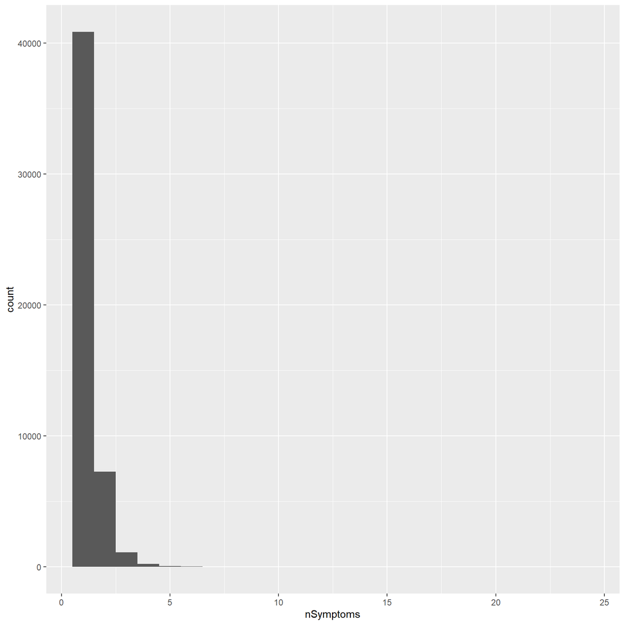

```r
vaersOverlap2020 %>% ggplot(aes(x=nSymptoms)) + geom_histogram(binwidth=1)
```

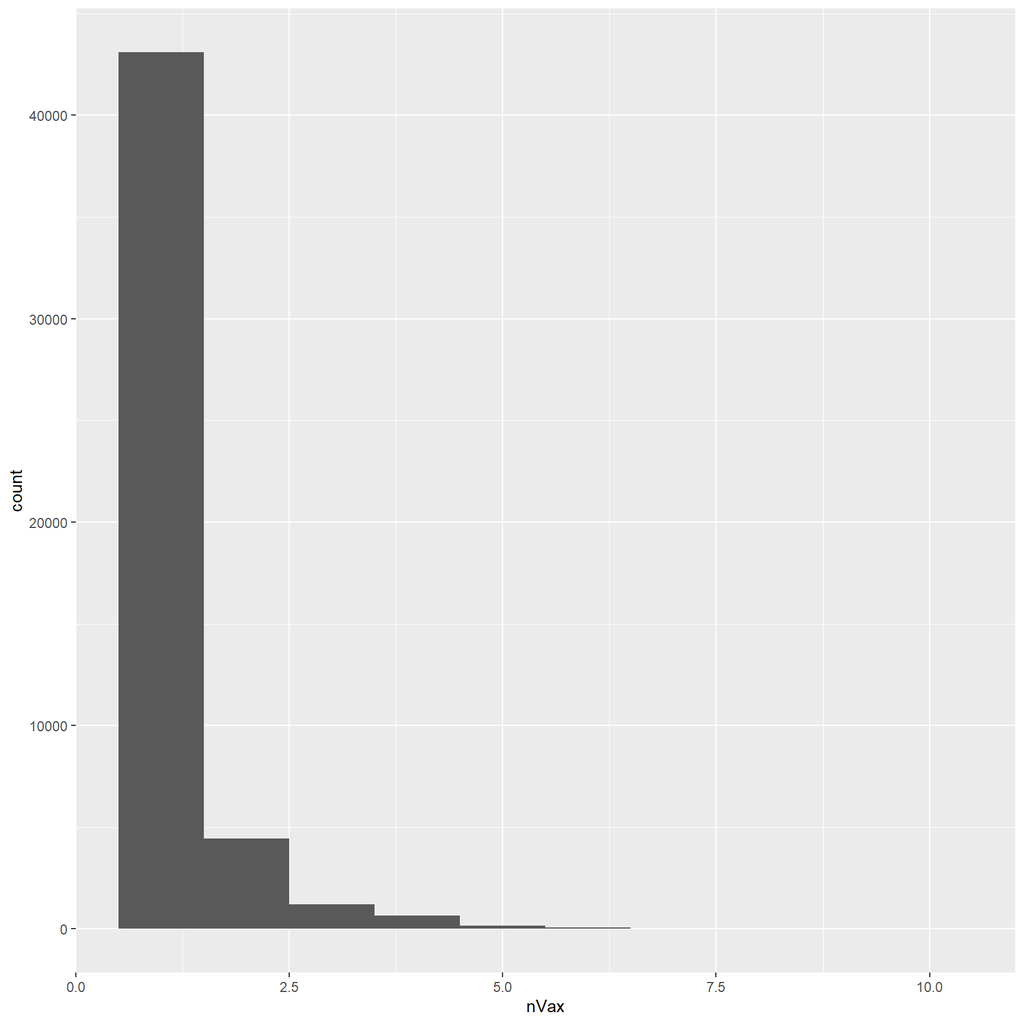

```r
vaersOverlap2020 %>% ggplot(aes(x=nVax)) + geom_histogram(binwidth=1)
```

```r
# Pull outlier VAERS_ID (roughly 1% of data has very many vaccines or very many symptoms)
vaersOutlier2020 <- vaersOverlap2020 %>%
    filter(nVax > 4 | nSymptoms > 4)
vaersOutlier2020
```

```
## # A tibble: 423 x 4
##    VAERS_ID nData nSymptoms  nVax
##    <chr>    <dbl>     <int> <int>
##  1 0855033      1         5     4
##  2 0855229      1         1     8
##  3 0855473      1         1     6
##  4 0855509      1         8     1
##  5 0855674      1         1     5
##  6 0855704      1         1     5
##  7 0855841      1         6     1
##  8 0855975      1         5     1
##  9 0856025      1         2     5
## 10 0856029      1         5     1
## # ... with 413 more rows
```

```r
# Example data
set.seed(22062422)
vaersCheck <- vaersOutlier2020 %>% sample_n(size=5)
vaersCheck
```

```
## # A tibble: 5 x 4
##   VAERS_ID nData nSymptoms  nVax
##   <chr>    <dbl>     <int> <int>
## 1 0870057      1         6     1
## 2 0872237      1         1     5
## 3 0885254      1         1     5
## 4 0856652      1         1     5
## 5 0887856      1         1     5
```

```r
vaersSymptoms2020 %>%
    right_join(vaersCheck, by="VAERS_ID")
```

```
## # A tibble: 10 x 14
##    VAERS_ID SYMPTOM1    SYMPTOMVERSION1 SYMPTOM2    SYMPTOMVERSION2 SYMPTOM3
##    <chr>    <chr>       <chr>           <chr>       <chr>           <chr>
##  1 0856652  Injection ~ 23.00           <NA>        <NA>            <NA>
##  2 0870057  Angiogram   23.00           Arteriogra~ 23.00           Ataxia
##  3 0870057  Cerebral i~ 23.00           Cerebral m~ 23.00           Cerebrovasc~
##  4 0870057  Embolic ce~ 23.00           Facial par~ 23.00           Facial pare~
##  5 0870057  Intensive ~ 23.00           Ischaemic ~ 23.00           Magnetic re~
##  6 0870057  Nervous sy~ 23.00           Plasminoge~ 23.00           Product use~
##  7 0870057  Tremor      23.00           Ultrasound~ 23.00           <NA>
##  8 0872237  Autism spe~ 23.00           Hyperacusis 23.00           Language di~
##  9 0885254  Irritabili~ 23.10           Screaming   23.10           <NA>
## 10 0887856  Erythema    23.10           Rash eryth~ 23.10           Rash maculo~
## # ... with 8 more variables: SYMPTOMVERSION3 <chr>, SYMPTOM4 <chr>,
## #   SYMPTOMVERSION4 <chr>, SYMPTOM5 <chr>, SYMPTOMVERSION5 <chr>, nData <dbl>,
## #   nSymptoms <int>, nVax <int>
```

```r
vaersVax2020 %>%
    right_join(vaersCheck, by="VAERS_ID")
```

```
## # A tibble: 21 x 11
##    VAERS_ID VAX_TYPE  VAX_MANU        VAX_LOT VAX_DOSE_SERIES VAX_ROUTE VAX_SITE
##    <chr>    <chr>     <chr>           <chr>   <chr>           <chr>     <chr>
##  1 0856652  HEPA      "MERCK & CO. I~ S020241 1               IM        LL
##  2 0856652  HIBV      "MERCK & CO. I~ S016869 3               IM        LL
##  3 0856652  MMR       "MERCK & CO. I~ S006647 1               SC        RL
##  4 0856652  PNC13     "PFIZER\\WYETH" AR1657  4               IM        RL
##  5 0856652  VARCEL    "MERCK & CO. I~ S021924 1               SC        LL
##  6 0870057  VARZOS    "GLAXOSMITHKLI~ <NA>    UNK             OT        <NA>
##  7 0872237  DTAPHEPB~ "GLAXOSMITHKLI~ AC21B3~ UNK             SYR       RA
##  8 0872237  FLU3      "SANOFI PASTEU~ U4711da UNK             SYR       LL
##  9 0872237  HIBV      "SANOFI PASTEU~ uh769ab UNK             SYR       LL
## 10 0872237  HIBV      "SANOFI PASTEU~ AHAVB5~ UNK             SYR       RA
## # ... with 11 more rows, and 4 more variables: VAX_NAME <chr>, nData <dbl>,
## #   nSymptoms <int>, nVax <int>
```

The VAERS symptoms data can be pivoted longer so that it is unique by VAERS_ID and SYMPTOM:

```r
vaersSymptomsPivot2020 <- vaersSymptoms2020 %>%
    pivot_longer(-VAERS_ID) %>%
    filter(!is.na(value)) %>%
    mutate(type=ifelse(stringr::str_detect(name, pattern="VERSION"), "code", "symptom")) %>%
    group_by(VAERS_ID, type) %>%
    mutate(number=row_number()) %>%
    ungroup() %>%
    pivot_wider(c(VAERS_ID, number), names_from="type", values_from="value") %>%
    checkUniqueRows(uniqueBy=c("VAERS_ID", "symptom"))
```

```
##
## *** File has been checked for uniqueness by: VAERS_ID symptom
```

```r
vaersSymptomsPivot2020
```

```
## # A tibble: 178,542 x 4
##    VAERS_ID number symptom                          code
##    <chr>     <int> <chr>                            <chr>
##  1 0855017       1 Arthralgia                       22.10
##  2 0855017       2 Chills                           22.10
##  3 0855017       3 Injection site pain              22.10
##  4 0855017       4 Pyrexia                          22.10
##  5 0855018       1 Chills                           22.10
##  6 0855018       2 Fatigue                          22.10
##  7 0855018       3 Hypertension                     22.10
##  8 0855018       4 Hypoaesthesia                    22.10
##  9 0855018       5 Injected limb mobility decreased 22.10
## 10 0855018       6 Muscular weakness                22.10
## # ... with 178,532 more rows
```

```r
colSums(is.na(vaersSymptomsPivot2020))
```

```
## VAERS_ID   number  symptom     code
##        0        0        0        0
```

```r
vaersSymptomsPivot2020 %>% count(symptom, sort=TRUE)
```

```
## # A tibble: 4,055 x 2
##    symptom                     n
##    <chr>                   <int>
##  1 Pyrexia                  6674
##  2 Headache                 6269
##  3 Pain                     6152
##  4 Injection site pain      5270
##  5 Chills                   5146
##  6 Pain in extremity        4850
##  7 Fatigue                  4622
##  8 No adverse event         4285
##  9 Nausea                   3982
## 10 Injection site erythema  3808
## # ... with 4,045 more rows
```

```r
vaersSymptomsPivot2020 %>% count(code, sort=TRUE)
```

```
## # A tibble: 4 x 2
##   code       n
##   <chr>  <int>
## 1 23.10 102114
## 2 23.00  51837
## 3 24.00  12467
## 4 22.10  12124
```

Data are limited to vaccines received in 2020 (some reports in 2020 are for events in previous years, some events in 2020 will not be reported unitl 2021 or later), and evolution by month plotted:

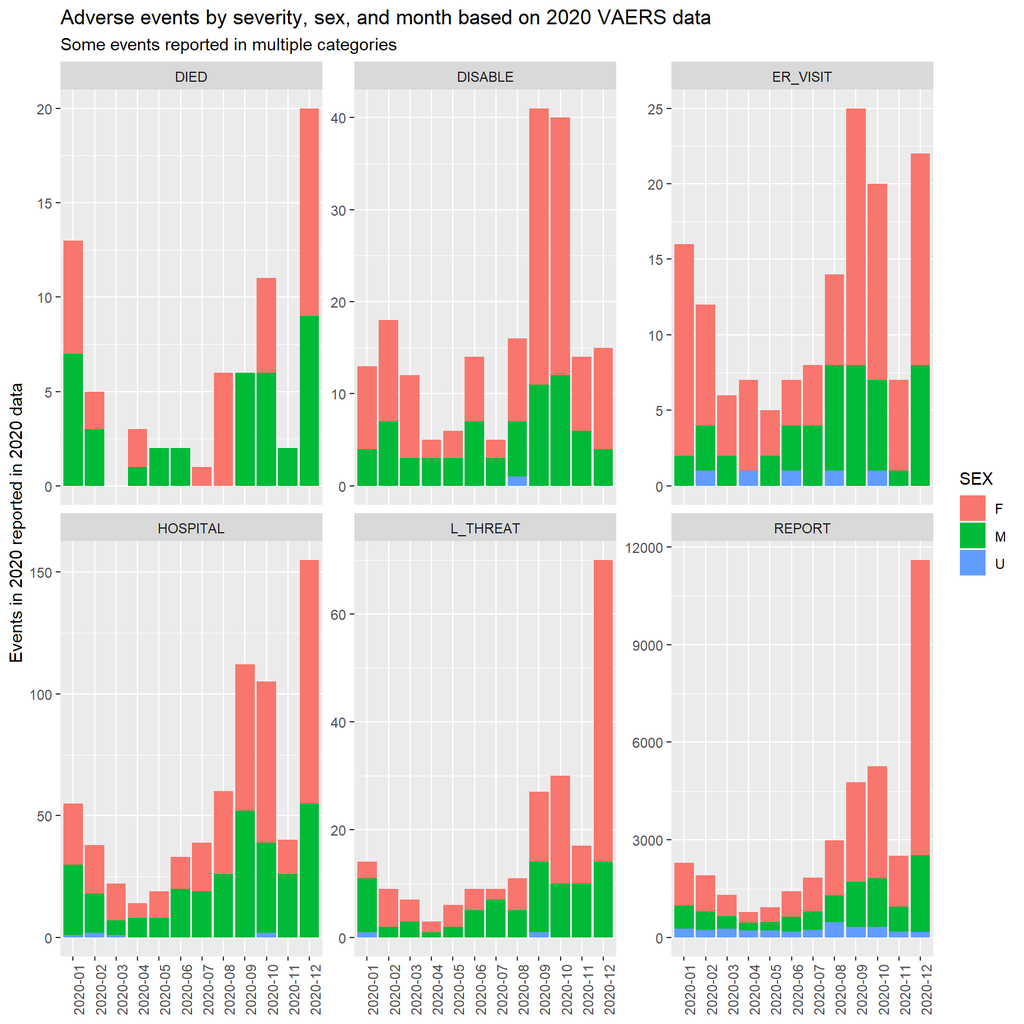

```r
vaersData2020 %>%
    filter(lubridate::year(VAX_DATE)==2020) %>%
    select(VAX_DATE, CAGE_YR, SEX, DIED, L_THREAT, ER_VISIT, HOSPITAL, DISABLE) %>%
    mutate(REPORT="Y", month=customYYYYMM(VAX_DATE)) %>%
    pivot_longer(-c(VAX_DATE, month, CAGE_YR, SEX)) %>%
    group_by(month, SEX, name) %>%
    summarize(nEvent=sum(ifelse(is.na(value), 0, 1)), n=n(), .groups="drop") %>%
    ggplot(aes(x=month, y=nEvent)) +
    geom_col(aes(group=SEX, fill=SEX), position="stack") +
    facet_wrap(~name, scales="free_y") +
    labs(title="Adverse events by severity, sex, and month based on 2020 VAERS data",
         subtitle="Some events reported in multiple categories",
         x=NULL,
         y="Events in 2020 reported in 2020 data"
         ) +
    theme(axis.text.x = element_text(angle=90))
```

The raw data loading processes are converted to functional form:

```r
readRawVAERS <- function(fileName,
                         fnRead=readr::read_csv,
                         colTypes=NULL,
                         convertDate=c(),
                         checkUnique=FALSE,
                         glimpseFile=TRUE,
                         ...
                         ) {

    # FUNCTION ARGUMENTS:
    # fileName: location of the CSV file to be read
    # fnRead: the function to be used in reading the file
    # colTypes: character vector of data types by column (NULL means let read_csv guess)
    # convertDate: columns to be converted to date using lubridate::mdy
    # checkUnique: confirm that file is unique by this variable (NULL means check full record; FALSE means do not check)
    # glimpseFile: boolean, should the file be glimpsed?
    # ...: other arguments passed to fileRead (which will be further passed to read_csv)

    # Read the VAERS data file and convert dates
    df <- fileRead(fileName, fnRead=fnRead, col_types=colTypes, ...) %>%
        mutate(across(all_of(convertDate), .fns=function(x) lubridate::mdy(x)))

    # Check for uniqueness if requested
    if(!isFALSE(checkUnique)) df %>% checkUniqueRows(uniqueBy=checkUnique, returnDF=FALSE)

    # Glimpse the file if requested
    if(isTRUE(glimpseFile)) glimpse(df)

    # Return the file
    df

}

# Individual functions to read each of three files
readRawVAERSData <- function(fileName, glimpseFile=TRUE, ...) {

    # FUNCTION ARGUMENTS:
    # fileName: file to be read
    # glimpseFile: boolean, should the file be glimpsed?
    # ...: other arguments to be passed to read_csv

    readRawVAERS(fileName,
                 colTypes="cccdddccccccccdcccccdccccccccdccccc",
                 convertDate=c("RECVDATE", "RPT_DATE", "DATEDIED", "VAX_DATE", "ONSET_DATE", "TODAYS_DATE"),
                 checkUnique="VAERS_ID",
                 glimpseFile=glimpseFile,
                 ...
                 )

}

readRawVAERSSymptoms <- function(fileName, glimpseFile=TRUE, ...) {

    # FUNCTION ARGUMENTS:
    # fileName: file to be read
    # glimpseFile: boolean, should the file be glimpsed?
    # ...: other arguments to be passed to read_csv

    readRawVAERS(fileName,
                 colTypes="ccccccccccc",
                 checkUnique=NULL,
                 glimpseFile=glimpseFile,
                 ...
                 )
}

readRawVAERSVax <- function(fileName, glimpseFile=TRUE, ...) {

    # FUNCTION ARGUMENTS:
    # fileName: file to be read
    # glimpseFile: boolean, should the file be glimpsed?
    # ...: other arguments to be passed to read_csv

    readRawVAERS(fileName,
                 checkUnique=FALSE,
                 glimpseFile=glimpseFile,
                 ...
                 )
}

# Check that same data is returned
identical(readRawVAERSData("./RInputFiles/Coronavirus/VAERS/Explore2020/2020VAERSDATA.csv", glimpseFile=FALSE),
          vaersData2020
          )
```

```
##
## *** File has been checked for uniqueness by: VAERS_ID
```

```
## [1] TRUE
```

```r
identical(readRawVAERSSymptoms("./RInputFiles/Coronavirus/VAERS/Explore2020/2020VAERSSYMPTOMS.csv", glimpseFile=FALSE),
          vaersSymptoms2020
          )
```

```
##
## *** File has been checked for uniqueness by: VAERS_ID SYMPTOM1 SYMPTOMVERSION1 SYMPTOM2 SYMPTOMVERSION2 SYMPTOM3 SYMPTOMVERSION3 SYMPTOM4 SYMPTOMVERSION4 SYMPTOM5 SYMPTOMVERSION5
```

```
## [1] TRUE
```

```r
identical(readRawVAERSVax("./RInputFiles/Coronavirus/VAERS/Explore2020/2020VAERSVAX.csv", glimpseFile=FALSE),
          vaersVax2020
          )
```

```
## [1] TRUE
```

Additional processing can be run to ensure uniqueness of the vaccines data and convert the symptoms data so there is one row for each symptom-patient:

```r
processRawVAERS <- function(dfMain=NULL,
                            dfSymptoms=NULL,
                            dfVax=NULL
                            ) {

    # FUNCTION ARGUMENTS:
    # dfMain: the main VAERS data file (NULL means do not use)
    # dfSymptoms: the symptoms data file (NULL means do not use)
    # dfVax: the vaccines data file (NULL means do not use)

    # Convert the symptoms to be unique by VAERS_ID-SYMPTOM
    if(!is.null(dfSymptoms)) {
        dfSymptoms <- dfSymptoms %>%
            pivot_longer(-VAERS_ID) %>%
            filter(!is.na(value)) %>%
            mutate(type=ifelse(stringr::str_detect(name, pattern="VERSION"), "code", "symptom")) %>%
            group_by(VAERS_ID, type) %>%
            mutate(number=row_number()) %>%
            ungroup() %>%
            pivot_wider(c(VAERS_ID, number), names_from="type", values_from="value") %>%
            checkUniqueRows(uniqueBy=c("VAERS_ID", "symptom"), severity="warning")
        glimpse(dfSymptoms)
        cat("\nNA record counts in pivoted symptoms data:\n")
        colSums(is.na(dfSymptoms)) %>% print()
        cat("\nCounts of top symptoms, codes, and number of symptoms in pivoted symptoms data:\n")
        dfSymptoms %>% count(symptom, sort=TRUE) %>% print()
        dfSymptoms %>% count(code, sort=TRUE) %>% print()
        dfSymptoms %>% count(number, sort=TRUE) %>% print()
    }

    # Convert the vaccines data to be unique
    if(!is.null(dfVax)) {
        dfVax <- dfVax %>%
            group_by_at(all_of(names(dfVax))) %>%
            summarize(nRecords=n(), .groups="drop") %>%
            checkUniqueRows(uniqueBy=names(dfVax), severity="warning")
        glimpse(dfVax)
        cat("\nOccurences per vaccine record in raw VAERS vaccines data")
        dfVax %>% count(nRecords, sort=TRUE) %>% print()
    }

    # Check overlap of data if all datasets passed
    if(!is.null(dfMain) & !is.null(dfSymptoms) & !is.null(dfVax)) {
        # Create overlap database
        dfOverlap <- dfMain %>%
            select(VAERS_ID) %>%
            mutate(nData=1) %>%
            full_join(dfSymptoms %>% group_by(VAERS_ID) %>% summarize(nSymptoms=max(number)), by="VAERS_ID") %>%
            full_join(count(dfVax, VAERS_ID, name="nVax"), by="VAERS_ID") %>%
            checkUniqueRows(uniqueBy="VAERS_ID")
        # Confirm that every VAERS_ID is in each file
        cat("\nChecking that overlap of main-symptoms-vax has zero NA (each VAERS_ID is in each file)\n")
        colSums(is.na(dfOverlap)) %>% print()
        cat("\n")
    }

    # Return a list of the processed data (or pass-through of NULL for data not provided)
    list(dfMain=dfMain, dfSymptoms=dfSymptoms, dfVax=dfVax)

}

processVAERS2020 <- processRawVAERS(dfMain=vaersData2020, dfSymptoms=vaersSymptoms2020, dfVax=vaersVax2020)
```

```
##
## *** File has been checked for uniqueness by: VAERS_ID symptom
##
## Rows: 178,542
## Columns: 4
## $ VAERS_ID <chr> "0855017", "0855017", "0855017", "0855017", "0855018", "08550~
## $ number   <int> 1, 2, 3, 4, 1, 2, 3, 4, 5, 6, 7, 8, 9, 10, 1, 2, 3, 1, 2, 3, ~
## $ symptom  <chr> "Arthralgia", "Chills", "Injection site pain", "Pyrexia", "Ch~
## $ code     <chr> "22.10", "22.10", "22.10", "22.10", "22.10", "22.10", "22.10"~
##
## NA record counts in pivoted symptoms data:
## VAERS_ID   number  symptom     code
##        0        0        0        0
##
## Counts of top symptoms, codes, and number of symptoms in pivoted symptoms data:
## # A tibble: 4,055 x 2
##    symptom                     n
##    <chr>                   <int>
##  1 Pyrexia                  6674
##  2 Headache                 6269
##  3 Pain                     6152
##  4 Injection site pain      5270
##  5 Chills                   5146
##  6 Pain in extremity        4850
##  7 Fatigue                  4622
##  8 No adverse event         4285
##  9 Nausea                   3982
## 10 Injection site erythema  3808
## # ... with 4,045 more rows
## # A tibble: 4 x 2
##   code       n
##   <chr>  <int>
## 1 23.10 102114
## 2 23.00  51837
## 3 24.00  12467
## 4 22.10  12124
## # A tibble: 117 x 2
##    number     n
##     <int> <int>
##  1      1 49651
```

[output cut: 28 more lines]

```
## 1        1 59273
## 2        2   123
## 3        3    24
## 4       10     4
## 5        4     3
## 6        5     1
## 7        6     1
## 8        7     1
##
## *** File has been checked for uniqueness by: VAERS_ID
##
##
## Checking that overlap of main-symptoms-vax has zero NA (each VAERS_ID is in each file)
##  VAERS_ID     nData nSymptoms      nVax
##         0         0         0         0
```

```r
identical(vaersData2020, processVAERS2020$dfMain)
```

```
## [1] TRUE
```

```r
identical(vaersSymptomsPivot2020, processVAERS2020$dfSymptoms)
```

```
## [1] TRUE
```

```r
# Making vaccines data unique changes sort order of some components for records with multiple vaccines
all.equal(unique(vaersVax2020) %>% arrange(VAERS_ID, VAX_DOSE_SERIES, VAX_LOT, VAX_ROUTE, VAX_SITE),
          select(processVAERS2020$dfVax, -nRecords) %>% arrange(VAERS_ID, VAX_DOSE_SERIES, VAX_LOT, VAX_ROUTE, VAX_SITE)
          )
```

```
## [1] TRUE
```

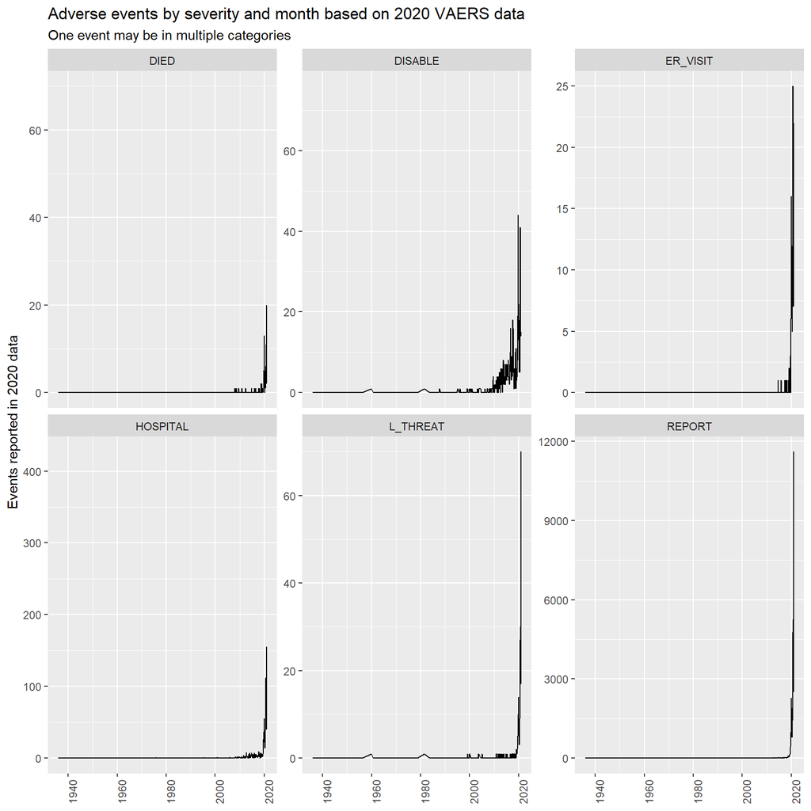

```r
plotVAERSMonthly <- function(lst,
                             vaxYears=NULL,
                             plotVars=c("DIED", "L_THREAT", "ER_VISIT", "HOSPITAL", "DISABLE", "REPORT"),
                             segVars=c(),
                             monthAsChar=if(length(segVars)>0) TRUE else FALSE,
                             plotTitle=NULL,
                             plotSubtitle=if(length(plotVars) > 1) "One event may be in multiple categories" else NULL,
                             plotYLabel=NULL,
                             plotXLabel=NULL,
                             printPlot=TRUE,
                             returnDF=FALSE
                             ) {

    # FUNCTION ARGUMENTS:
    # lst: list of processed VAERS data
    # vaxYears: which years of vaccination should be included (NULL means all)
    # plotVars: variables of interest (facets if length greater than 1)
    # segVars: demographic variables of interest
    # monthAsChar: boolean, should month be treated as a character variable (rather than converted to date)?
    # plotTitle: title for the plot
    # plotSubTitle: subtitle for the plot
    # plotYLabel: y-label for the plot
    # plotXLabel: x-label for the plot
    # printPlot: boolean, should the plot be printed?
    # returnDF: boolean, should the data frame be returned?

    # Extract data
    df <- lst[["dfMain"]]

    # Filter for years if requested
    if(!is.null(vaxYears)) df <- df %>% filter(lubridate::year(VAX_DATE) %in% all_of(vaxYears))

    # Create the custom date and reporting flag, keep only relevant variables, pivot, and count
    df <- df %>%
        mutate(month=customYYYYMM(VAX_DATE), REPORT="Y") %>%
        select(all_of(c("month", plotVars, segVars))) %>%
        pivot_longer(-all_of(c("month", segVars))) %>%
        group_by_at(all_of(c("month", segVars, "name"))) %>%
        summarize(nEvent=sum(ifelse(is.na(value), 0, 1)), n=n(), .groups="drop")

    # Create the plot
    p1 <- df %>%
        ggplot(aes(x=if(isTRUE(monthAsChar)) month else lubridate::ym(month), y=nEvent)) +
        labs(title=plotTitle,
             subtitle=plotSubtitle,
             x=plotXLabel,
             y=plotYLabel
             ) +
        theme(axis.text.x = element_text(angle=90))

    # Add a line plot if there are no segments, bar plot otherwise
    if(length(segVars)==0) p1 <- p1 + geom_line()
    else p1 <- p1 +
        geom_col(aes(group=get(segVars), fill=get(segVars)), position="stack") +
        scale_fill_discrete(segVars)

    # Add facets if relevant
    if(length(plotVars) > 1) p1 <- p1 + facet_wrap(~name, scales="free_y")

    # Print the plot
    if(isTRUE(printPlot)) print(p1)

    # Return the data frame
    if(isTRUE(returnDF)) return(df)

}

plotVAERSMonthly(processVAERS2020,
                 plotTitle="Adverse events by severity and month based on 2020 VAERS data",
                 plotYLabel="Events reported in 2020 data"
                 )
```

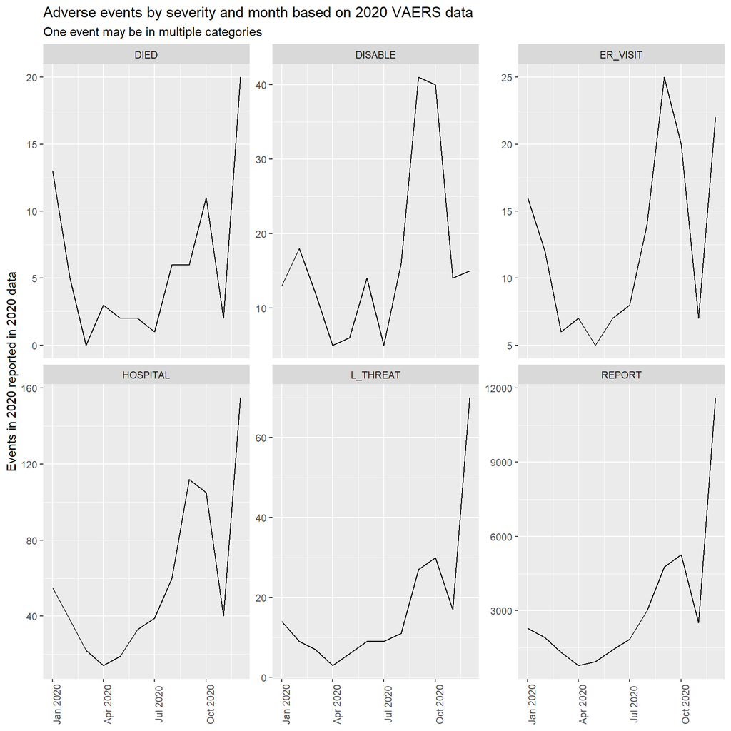

```r
plotVAERSMonthly(processVAERS2020,
                 vaxYears=2020,
                 plotTitle="Adverse events by severity and month based on 2020 VAERS data",
                 plotYLabel="Events in 2020 reported in 2020 data"
                 )
```

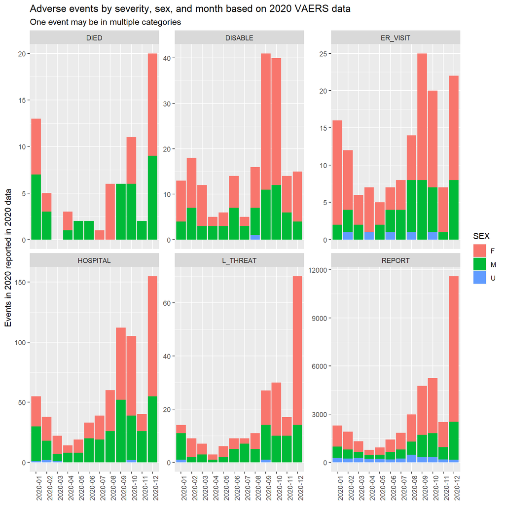

```
## # A tibble: 216 x 5
##    month   SEX   name     nEvent     n
##    <chr>   <chr> <chr>     <dbl> <int>
##  1 2020-01 F     DIED          6  1302
##  2 2020-01 F     DISABLE       9  1302
##  3 2020-01 F     ER_VISIT     14  1302
##  4 2020-01 F     HOSPITAL     25  1302
##  5 2020-01 F     L_THREAT      3  1302
##  6 2020-01 F     REPORT     1302  1302
##  7 2020-01 M     DIED          7   710
##  8 2020-01 M     DISABLE       4   710
##  9 2020-01 M     ER_VISIT      2   710
## 10 2020-01 M     HOSPITAL     29   710
## # ... with 206 more rows
```

```r
plotVAERSMonthly(processVAERS2020,
                 vaxYears=2020,
                 segVars="SEX",
                 plotTitle="Adverse events by severity, sex, and month based on 2020 VAERS data",
                 plotYLabel="Events in 2020 reported in 2020 data",
                 returnDF=TRUE
                 )
```

A function is written to create a skinnier version of processed data:

```r
makeSkinnyVAERSList <- function(lst,
                                excludeMain=c("SYMPTOM_TEXT"),
                                excludeVax=c(),
                                excludeSymptoms=c(),
                                makeSymptomMap=TRUE
                                ) {

    # FUNCTION ARGUMENTS:
    # lst: an initial list file
    # excludeMain: variables to exclude from dfMain (symptoms are in a separate file)
    # excludeVax: variables to exclude from dfVax
    # excludeSymptoms: variables to exclude from dfSymptoms
    # makeSymptomMap: should dfSymptoms be made relational by moving symptom text to a separate file?
    #                 will replace symptom with the relevant code

    # Apply the symptom mapping if relevant
    if(isTRUE(makeSymptomMap)) {
        symptomMap <- lst[["dfSymptoms"]] %>% count(symptom) %>% mutate(symptomID=as.integer(row_number()))
        dfSymptoms <- lst[["dfSymptoms"]] %>%
            left_join(select(symptomMap, symptom, symptomID), by="symptom") %>%
            select(-symptom) %>%
            rename(symptom=symptomID)
    }
    else {
        symptomMap <- NULL
        dfSymptoms <- lst[["dfSymptoms"]]
    }

    # Create the skinny list
    list(dfMain=lst[["dfMain"]] %>% select(-all_of(excludeMain)),
         dfSymptoms=dfSymptoms,
         dfVax=lst[["dfVax"]] %>% select(-all_of(excludeVax)),
         symptomMap=symptomMap
         )

}

tmpOrigSize <- object.size(processVAERS2020)
tmpNewSize <- object.size(makeSkinnyVAERSList(processVAERS2020))
cat("\nOld object size: ",
    round(tmpOrigSize/1024/1024, 1),
    " GB and new object size: ",
    round(tmpNewSize/1024/1024, 1),
    " GB (",
    round(100*(1-tmpNewSize/tmpOrigSize), 1),
    "% reduction)\n",
    sep=""
    )
```

```
##
## Old object size: 72 GB and new object size: 36.6 GB (49.1% reduction)
```

The 2019 data are loaded using skinny format:

```r
mainLoc <- "./RInputFiles/Coronavirus/VAERS/Explore2019/2019VAERSDATA.csv"
sympLoc <- "./RInputFiles/Coronavirus/VAERS/Explore2019/2019VAERSSYMPTOMS.csv"
vaxLoc <- "./RInputFiles/Coronavirus/VAERS/Explore2019/2019VAERSVAX.csv"

skinnyVAERS2019 <- processRawVAERS(dfMain=readRawVAERSData(mainLoc, glimpseFile=FALSE),
                                   dfSymptoms=readRawVAERSSymptoms(sympLoc, glimpseFile=FALSE),
                                   dfVax=readRawVAERSVax(vaxLoc, glimpseFile=FALSE)
                                   ) %>%
    makeSkinnyVAERSList()
```

```
##
## *** File has been checked for uniqueness by: VAERS_ID SYMPTOM1 SYMPTOMVERSION1 SYMPTOM2 SYMPTOMVERSION2 SYMPTOM3 SYMPTOMVERSION3 SYMPTOM4 SYMPTOMVERSION4 SYMPTOM5 SYMPTOMVERSION5
##
##
## *** File has been checked for uniqueness by: VAERS_ID symptom
##
## Rows: 181,163
## Columns: 4
## $ VAERS_ID <chr> "0794156", "0794156", "0794157", "0794157", "0794157", "07941~
## $ number   <int> 1, 2, 1, 2, 3, 4, 5, 6, 7, 8, 9, 10, 1, 2, 3, 4, 5, 1, 2, 3, ~
## $ symptom  <chr> "Injected limb mobility decreased", "Injection site joint pai~
## $ code     <chr> "21.10", "21.10", "21.10", "21.10", "21.10", "21.10", "21.10"~
##
## NA record counts in pivoted symptoms data:
## VAERS_ID   number  symptom     code
##        0        0        0        0
##
## Counts of top symptoms, codes, and number of symptoms in pivoted symptoms data:
## # A tibble: 4,114 x 2
##    symptom                     n
##    <chr>                   <int>
##  1 Pyrexia                  6988
##  2 No adverse event         6185
##  3 Injection site pain      5823
##  4 Pain                     5797
##  5 Injection site erythema  5463
##  6 Pain in extremity        4978
##  7 Headache                 4875
##  8 Chills                   4514
##  9 Injection site swelling  4171
## 10 Fatigue                  3877
## # ... with 4,104 more rows
## # A tibble: 5 x 2
##   code      n
##   <chr> <int>
## 1 22.00 92277
## 2 22.10 78664
## 3 21.10 10202
## 4 23.00    16
## 5 23.10     4
## # A tibble: 107 x 2
##    number     n
##     <int> <int>
##  1      1 48437
##  2      2 39502
##  3      3 26542
##  4      4 18974
##  5      5 13251
##  6      6  9057
##  7      7  6267
##  8      8  4377
##  9      9  3047
## 10     10  2137
## # ... with 97 more rows
```

```
##
## *** File has been checked for uniqueness by: VAERS_ID VAX_TYPE VAX_MANU VAX_LOT VAX_DOSE_SERIES VAX_ROUTE VAX_SITE VAX_NAME
##
## Rows: 61,093
## Columns: 9
## $ VAERS_ID        <chr> "0794156", "0794157", "0794158", "0794159", "0794159",~
## $ VAX_TYPE        <chr> "FLU4", "VARZOS", "VARZOS", "DTAPIPV", "MMRV", "VARZOS~
## $ VAX_MANU        <chr> "GLAXOSMITHKLINE BIOLOGICALS", "GLAXOSMITHKLINE BIOLOG~
## $ VAX_LOT         <chr> "JZ3B7", NA, NA, "G9P35", "R015744", NA, NA, "79D57", ~
## $ VAX_DOSE_SERIES <chr> "UNK", "UNK", "UNK", "1", "1", "1", "UNK", "1", "1", "~
## $ VAX_ROUTE       <chr> "IM", NA, NA, "IM", "SC", "IM", NA, "IM", "IM", "IM", ~
## $ VAX_SITE        <chr> "LA", NA, NA, "LL", "LL", "RA", NA, "LL", "RL", "LA", ~
## $ VAX_NAME        <chr> "INFLUENZA (SEASONAL) (FLUARIX QUADRIVALENT)", "ZOSTER~
## $ nRecords        <int> 1, 1, 1, 1, 1, 1, 1, 1, 1, 1, 1, 1, 1, 1, 1, 1, 1, 1, ~
##
## Occurences per vaccine record in raw VAERS vaccines data# A tibble: 5 x 2
##   nRecords     n
##      <int> <int>
## 1        1 61003
## 2        2    81
## 3        3     7
## 4        4     1
## 5        5     1
##
## *** File has been checked for uniqueness by: VAERS_ID
##
##
## *** File has been checked for uniqueness by: VAERS_ID
##
##
## Checking that overlap of main-symptoms-vax has zero NA (each VAERS_ID is in each file)
##  VAERS_ID     nData nSymptoms      nVax
##         0         0         1         0
```

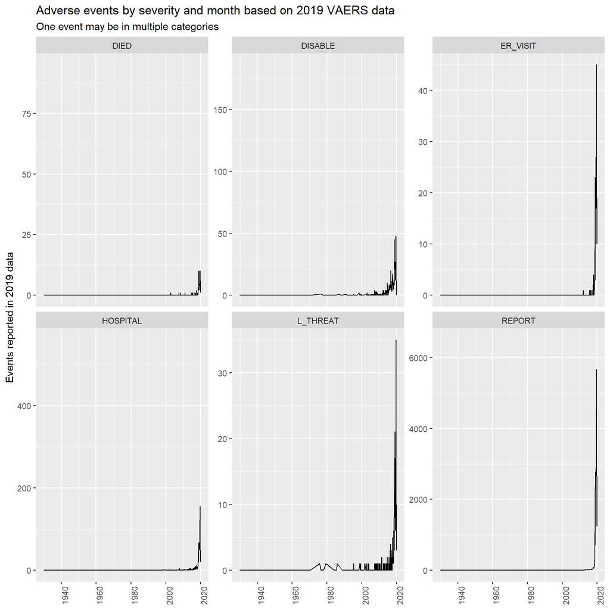

```r
plotVAERSMonthly(skinnyVAERS2019,
                 plotTitle="Adverse events by severity and month based on 2019 VAERS data",
                 plotYLabel="Events reported in 2019 data"
                 )
```

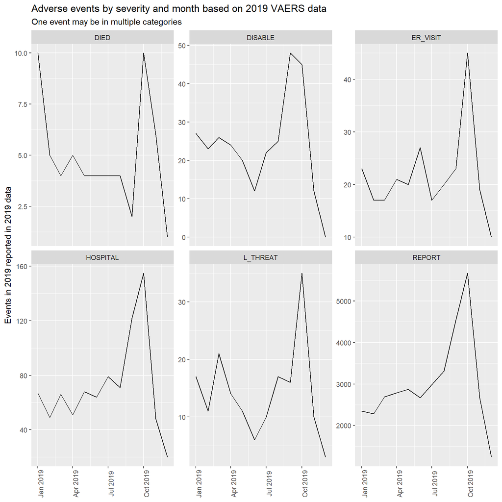

```r
plotVAERSMonthly(skinnyVAERS2019,
                 vaxYears=2019,
                 plotTitle="Adverse events by severity and month based on 2019 VAERS data",
                 plotYLabel="Events in 2019 reported in 2019 data"
                 )
```

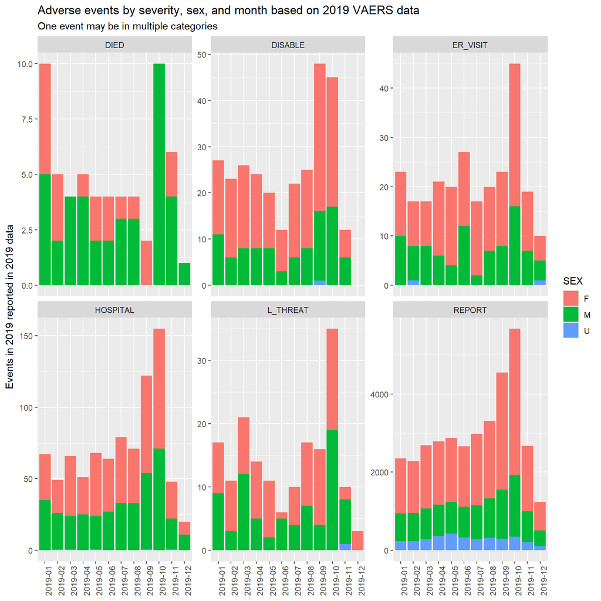

```
## # A tibble: 216 x 5
##    month   SEX   name     nEvent     n
##    <chr>   <chr> <chr>     <dbl> <int>
##  1 2019-01 F     DIED          5  1403
##  2 2019-01 F     DISABLE      16  1403
##  3 2019-01 F     ER_VISIT     13  1403
##  4 2019-01 F     HOSPITAL     32  1403
##  5 2019-01 F     L_THREAT      8  1403
##  6 2019-01 F     REPORT     1403  1403
##  7 2019-01 M     DIED          5   711
##  8 2019-01 M     DISABLE      11   711
##  9 2019-01 M     ER_VISIT     10   711
## 10 2019-01 M     HOSPITAL     35   711
## # ... with 206 more rows
```

```r
plotVAERSMonthly(skinnyVAERS2019,
                 vaxYears=2019,
                 segVars="SEX",
                 plotTitle="Adverse events by severity, sex, and month based on 2019 VAERS data",
                 plotYLabel="Events in 2019 reported in 2019 data",
                 returnDF=TRUE
                 )
```

The 2021 data are loaded using skinny format:

```r
mainLoc <- "./RInputFiles/Coronavirus/VAERS/Explore2021/2021VAERSDATA.csv"
sympLoc <- "./RInputFiles/Coronavirus/VAERS/Explore2021/2021VAERSSYMPTOMS.csv"
vaxLoc <- "./RInputFiles/Coronavirus/VAERS/Explore2021/2021VAERSVAX.csv"

skinnyVAERS2021 <- processRawVAERS(dfMain=readRawVAERSData(mainLoc, glimpseFile=FALSE),
                                   dfSymptoms=readRawVAERSSymptoms(sympLoc, glimpseFile=FALSE),
                                   dfVax=readRawVAERSVax(vaxLoc, glimpseFile=FALSE)
                                   ) %>%
    makeSkinnyVAERSList()
```

```
##
## *** File has been checked for uniqueness by: VAERS_ID SYMPTOM1 SYMPTOMVERSION1 SYMPTOM2 SYMPTOMVERSION2 SYMPTOM3 SYMPTOMVERSION3 SYMPTOM4 SYMPTOMVERSION4 SYMPTOM5 SYMPTOMVERSION5
```

```
##
## *** File has been checked for uniqueness by: VAERS_ID symptom
##
## Rows: 3,101,078
## Columns: 4
## $ VAERS_ID <chr> "0910642", "0910642", "0910642", "0916600", "0916600", "09166~
## $ number   <int> 1, 2, 3, 1, 2, 1, 2, 1, 2, 3, 4, 1, 2, 3, 1, 2, 3, 4, 1, 2, 3~
## $ symptom  <chr> "Dyspnoea", "Heart rate increased", "SARS-CoV-2 test negative~
## $ code     <chr> "25.00", "25.00", "25.00", "23.10", "23.10", "23.10", "23.10"~
##
## NA record counts in pivoted symptoms data:
## VAERS_ID   number  symptom     code
##        0        0        0        0
##
## Counts of top symptoms, codes, and number of symptoms in pivoted symptoms data:
## # A tibble: 11,066 x 2
##    symptom                n
##    <chr>              <int>
##  1 Headache          124249
##  2 Pyrexia           107555
##  3 Fatigue           104061
##  4 Pain               91744
##  5 Chills             91173
##  6 Nausea             70074
##  7 Dizziness          70019
##  8 Pain in extremity  69568
##  9 Myalgia            43401
## 10 Arthralgia         42484
## # ... with 11,056 more rows
## # A tibble: 4 x 2
##   code        n
##   <chr>   <int>
## 1 24.00 2246706
## 2 24.10  628651
## 3 23.10  222376
## 4 25.00    3345
## # A tibble: 131 x 2
##    number      n
##     <int>  <int>
##  1      1 736865
##  2      2 577011
##  3      3 442501
##  4      4 335326
##  5      5 247784
##  6      6 180404
##  7      7 131726
##  8      8  96556
##  9      9  71190
## 10     10  53041
## # ... with 121 more rows
```

```
##
## *** File has been checked for uniqueness by: VAERS_ID VAX_TYPE VAX_MANU VAX_LOT VAX_DOSE_SERIES VAX_ROUTE VAX_SITE VAX_NAME
##
## Rows: 778,925
## Columns: 9
## $ VAERS_ID        <chr> "0910642", "0916600", "0916601", "0916602", "0916603",~
## $ VAX_TYPE        <chr> "COVID19", "COVID19", "COVID19", "COVID19", "COVID19",~
## $ VAX_MANU        <chr> "PFIZER\\BIONTECH", "MODERNA", "MODERNA", "PFIZER\\BIO~
## $ VAX_LOT         <chr> "EJ1685", "037K20A", "025L20A", "EL1284", "unknown", N~
## $ VAX_DOSE_SERIES <chr> "1", "1", "1", "1", "UNK", "1", "1", "1", "UNK", "1", ~
## $ VAX_ROUTE       <chr> NA, "IM", "IM", "IM", NA, "IM", "SYR", "IM", "IM", "IM~
## $ VAX_SITE        <chr> "LA", "LA", "RA", "LA", NA, "LA", "LA", "LA", "LA", "L~
## $ VAX_NAME        <chr> "COVID19 (COVID19 (PFIZER-BIONTECH))", "COVID19 (COVID~
## $ nRecords        <int> 1, 1, 1, 1, 1, 1, 1, 1, 1, 1, 1, 1, 1, 1, 1, 1, 1, 1, ~
##
## Occurences per vaccine record in raw VAERS vaccines data# A tibble: 6 x 2
##   nRecords      n
##      <int>  <int>
## 1        1 777407
## 2        2   1455
## 3        3     44
## 4        4     16
## 5        5      2
## 6        7      1
##
## *** File has been checked for uniqueness by: VAERS_ID
##
##
## *** File has been checked for uniqueness by: VAERS_ID
##
##
## Checking that overlap of main-symptoms-vax has zero NA (each VAERS_ID is in each file)
##  VAERS_ID     nData nSymptoms      nVax
##         0         0         3         0
```

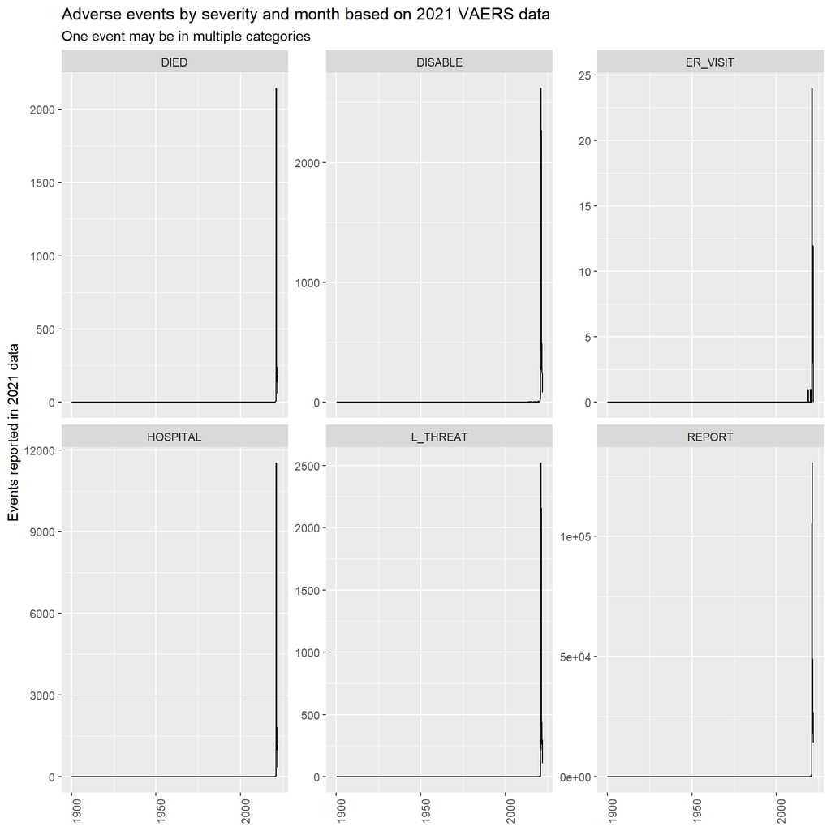

```r
plotVAERSMonthly(skinnyVAERS2021,
                 plotTitle="Adverse events by severity and month based on 2021 VAERS data",
                 plotYLabel="Events reported in 2021 data"
                 )
```

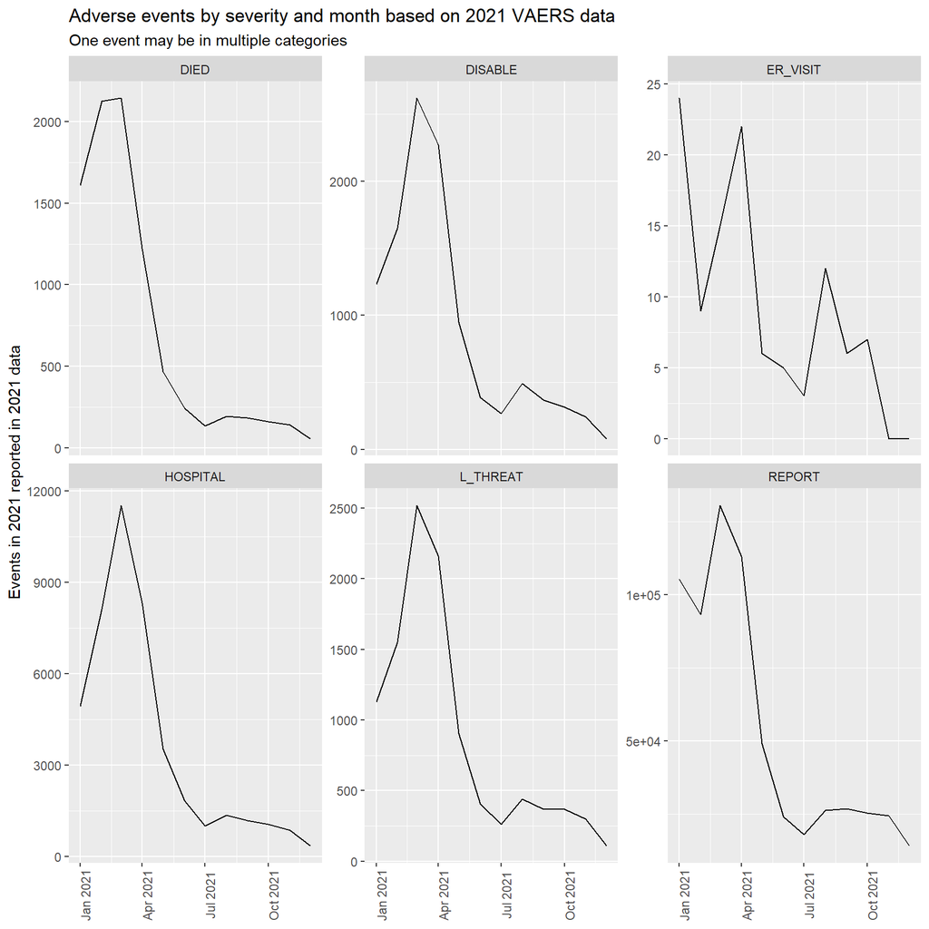

```r
plotVAERSMonthly(skinnyVAERS2021,
                 vaxYears=2021,
                 plotTitle="Adverse events by severity and month based on 2021 VAERS data",
                 plotYLabel="Events in 2021 reported in 2021 data"
                 )
```

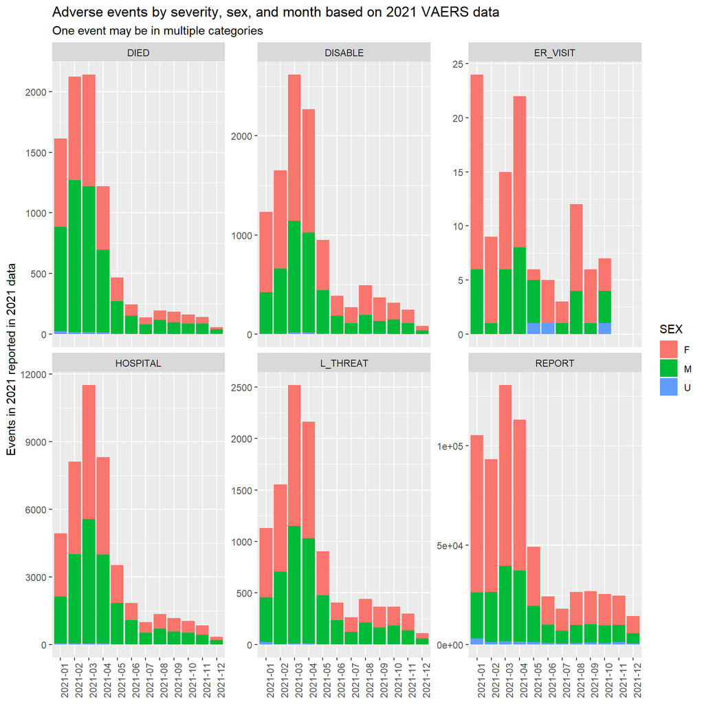

```
## # A tibble: 216 x 5
##    month   SEX   name     nEvent     n
##    <chr>   <chr> <chr>     <dbl> <int>
##  1 2021-01 F     DIED        727 79172
##  2 2021-01 F     DISABLE     810 79172
##  3 2021-01 F     ER_VISIT     18 79172
##  4 2021-01 F     HOSPITAL   2805 79172
##  5 2021-01 F     L_THREAT    672 79172
##  6 2021-01 F     REPORT    79172 79172
##  7 2021-01 M     DIED        861 23246
##  8 2021-01 M     DISABLE     418 23246
##  9 2021-01 M     ER_VISIT      6 23246
## 10 2021-01 M     HOSPITAL   2074 23246
## # ... with 206 more rows
```

```r
plotVAERSMonthly(skinnyVAERS2021,
                 vaxYears=2021,
                 segVars="SEX",
                 plotTitle="Adverse events by severity, sex, and month based on 2021 VAERS data",
                 plotYLabel="Events in 2021 reported in 2021 data",
                 returnDF=TRUE
                 )
```

```r
saveToRDS(skinnyVAERS2021, ovrWriteError=FALSE)
```